# UGC plan: Example Orbit: split-screen UGC

Campaign `example-orbit-app` for Example Orbit. Planned Wed 18 Nov 09:00 America/New_York (EST).  
3 videos for 3 accounts (2 posts through WoopSocial, 1 by hand). Everything goes out now, when you say yes, so you can submit each link within 30 minutes.

**Plan id `2df01d14d86f`.** To post exactly this, say yes to plan 2df01d14d86f. If any video, caption or setting changes after that, the yes no longer holds and you get a new page.

**EXAMPLE ONLY:** a made-up demo campaign. The brand, the app, the accounts and the links are invented, nothing here is a real ad, the creator's half is a placeholder, and NASA endorses nothing.

**Before you post**

- Post only from accounts connected and verified in an example marketplace (made up); posts from any other account are rejected.
- At least 40% of each video's viewers must be in the US, the UK, Canada, Australia. Post from the accounts whose viewers are already there, when they are awake. Never a VPN or location trick.
- Deadline: 2026-12-15 (America/New_York).
- This brief takes 3 submissions. Per video, the platforms rank: TikTok ($18.00 at 10,000 views, pays from 2,500), Instagram Reels ($18.00 at 10,000 views, pays from 2,500), YouTube Shorts ($9.00 at 10,000 views, pays from 5,000). A second video on the best platform can earn more than one on the weakest. Your call.
- Posting all at once means every in-app step and submission inside the same 30 minutes. Add "stagger": true to job.json to send one post at a time, each with its own clock.

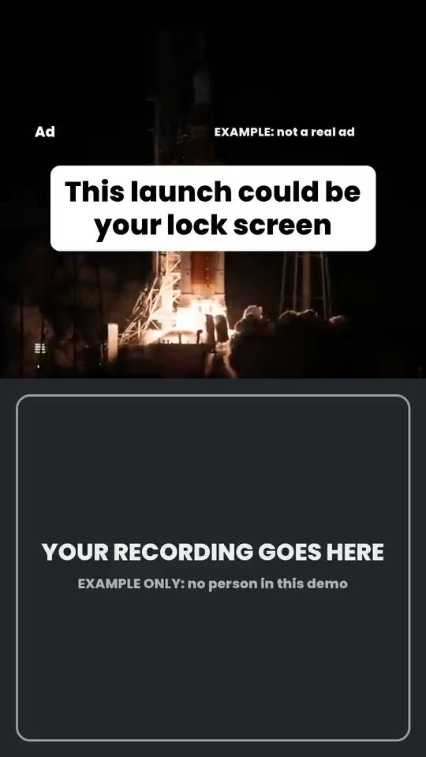

### TikTok @example.creator

TikTok · post orbit-tiktok · 22.3 s · split screen

all checks passed

Opens with

This launch could be your lock screen

Disclosure

“Ad” from the first frame for 3 s; said out loud at 6.3 s (estimated: placeholder, no audio)

Caption

#ad This launch could be your lock screen: a new space photo every day. Example Orbit, made-up app for this demo @example.orbit #exampleorbit #space

seen by everyonecomments onduets offstitches offbranded content on ("Paid partnership" label)by posting, you agree to TikTok's Branded Content Policy and Music Usage Confirmationno auto music

Expected earnings

$2.00 per 1,000 views, 10% fee (the $5.00 minimum applies to the amount before the fee). Pays nothing under 2,500 views. 1,000 views: $0.00; 10,000 views: $18.00; 100,000 views: $180.00. Cap $200.00 per video, reached at 100,000 views.

- placeholder take: the skill's example has no person in it. A real video is your own recording

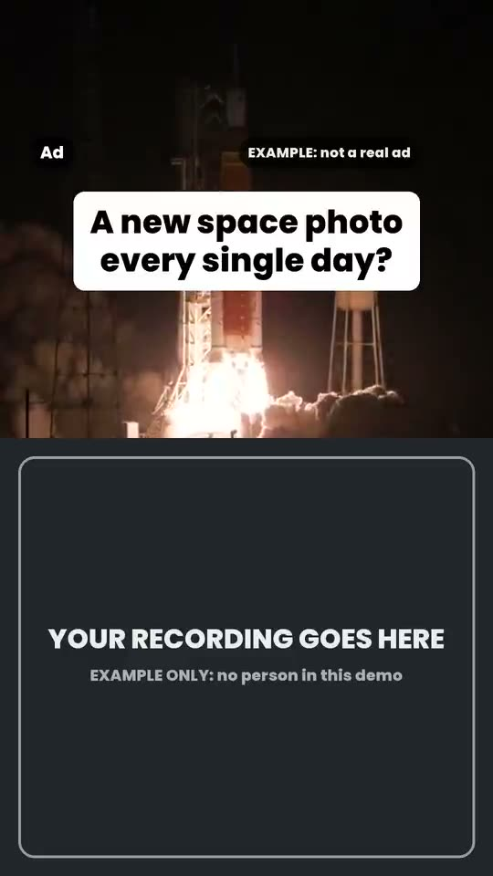

### Reels @example.creator

Instagram Reels · post orbit-reels · 22.3 s · split screen

all checks passed

Opens with

A new space photo every single day?

Disclosure

“Ad” from the first frame for 3 s; said out loud at 6.3 s (estimated: placeholder, no audio)

Caption

#ad A new space photo every day, two taps to make it your wallpaper. @example.orbit #exampleorbit #space

Reelpaid partnership label: you turn it on in the app

Expected earnings

$2.00 per 1,000 views, 10% fee (the $5.00 minimum applies to the amount before the fee). Pays nothing under 2,500 views. 1,000 views: $0.00; 10,000 views: $18.00; 100,000 views: $180.00. Cap $200.00 per video, reached at 100,000 views.

- placeholder take: the skill's example has no person in it. A real video is your own recording

Inside the 30 minutes

- Instagram: edit the Reel in the app and turn on the paid partnership label (add Example Orbit as partner if the brief asks). WoopSocial can't set it.

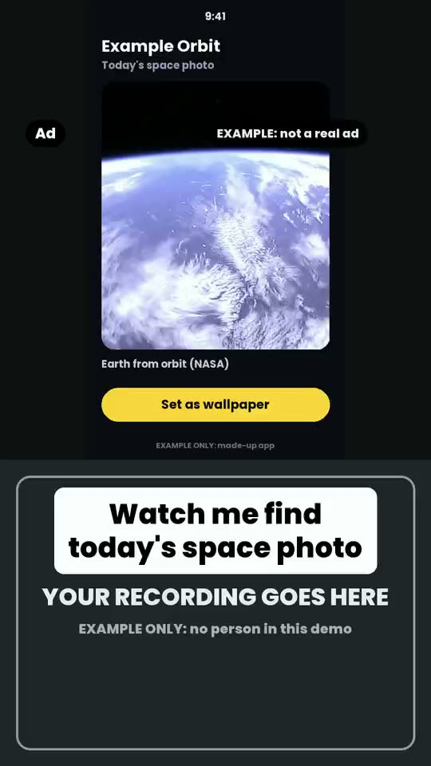

### Shorts @examplecreator

YouTube Shorts · post orbit-shorts · 21.9 s · face screen

all checks passed by hand

Opens with

Watch me find today's space photo

Disclosure

“Ad” from the first frame for 3 s; said out loud at 5.9 s (estimated: placeholder, no audio)

Title and description

Finding today's space photo

#ad Watch me find today's space photo and save it as a wallpaper in Example Orbit (a made-up app). @example.orbit #exampleorbit

publicnot made for kids"includes paid promotion": you tick it in YouTube Studio

Expected earnings

$1.00 per 1,000 views, 10% fee (the $5.00 minimum applies to the amount before the fee). Pays nothing under 5,000 views. 1,000 views: $0.00; 10,000 views: $9.00; 100,000 views: $90.00. Cap $200.00 per video, reached at 200,000 views.

- placeholder take: the skill's example has no person in it. A real video is your own recording

Inside the 30 minutes

- YouTube: in YouTube Studio open the Short's details and tick that it includes paid promotion. WoopSocial can't set it.

## Files to upload

Only after the yes, once each:

- `videos/reels.mp4` (0.6 MB, fingerprint `d3ff1d44edaf61a2`)
- `videos/tiktok.mp4` (0.6 MB, fingerprint `8175e9d2b69bcf34`)

## By hand

- `by-hand/orbit-shorts.md`

## After it's live

- Submit every link within 30 minutes, into this campaign only, once. `submit.md` gives the clock time per post and when to take the proof screenshots.
- Leave every post public and unchanged for 30 days. Views count for 30 days from the day a video crosses the payout threshold.
- Earnings are estimates: the campaign's own count decides what is paid, and many videos earn little. Never buy views or join engagement groups: it is a permanent ban on the marketplaces.